# On the Relation Between the History of Changes and Bugs

```r
suppressWarnings(library(dplyr))
suppressWarnings(library(stringr))
suppressWarnings(library(sqldf))
suppressWarnings(library(ggplot2))
suppressWarnings(library(beanplot))
suppressWarnings(library(vioplot))
suppressWarnings(library(ggpubr))
suppressWarnings(library(qcc))
methods <-
  read.csv(
    "~/R/analysis/methods/allMethodsall.csv",
    stringsAsFactors = FALSE
  )
getTypeMethod <- function (x){

  splitRef <- strsplit(x, "\\.") #divide o nome do metodo pelo ponto
  #splitRef

  for(d in splitRef){
    r <- sub("[(].*", "", d) #remove os paramentros do metodo
  }
  #r #Nessa var tem os valores separados, só fazer um if e verificar se os dois ultimos são iguais, ai cai no caso do construtor

  nomeMetodo <- sub(".*[.]", "", x) #seleciona o nome do metodo
  nomeMetodoSemParam <- sub("[(].*", "", nomeMetodo) #remove os parametros
  #nomeMetodoSemParam #só verificar se é igual a toString

  getOuSet <- substring(nomeMetodoSemParam, 1, 3) #seleciona os 3 primeiros elementos do metodo
  #getOuSet # só verificar se é um get ou set

  if (getOuSet == "set" || getOuSet == "get"){
    return ("Getters/Setters")

  } else if (nomeMetodo == "toString"){
    return ("toString")

  } else if (r[length(r)] == r[length(r)-1]){
    return ("Constructor")

  } else {
    return ("Normal")
  }

}
# implementing the function:
ggpareto <- function(x, title, labelx) {

  #title <- deparse(substitute(x))

  x <- data.frame(modality = na.omit(x))

  Df <- x %>% group_by(modality) %>% summarise(frequency=n()) %>%
    arrange(desc(frequency))

  Df$modality <- ordered(Df$modality, levels = unlist(Df$modality, use.names = F))

  Df <- Df %>% mutate(modality_int = as.integer(modality),
                      cumfreq = cumsum(frequency), cumperc = cumfreq/nrow(x) * 100)
  nr <- nrow(Df)
  N <- sum(Df$frequency)

  Df_ticks <- data.frame(xtick0 = rep(nr +.55, 11), xtick1 = rep(nr +.59, 11),
                         ytick = seq(0, N, N/10))

  y2 <- c("  0%", " 10%", " 20%", " 30%", " 40%", " 50%", " 60%", " 70%", " 80%", " 90%", "100%")

  g <- ggplot(Df, aes(x=modality, y=frequency)) +
    geom_bar(stat="identity", aes(fill = modality_int)) +
    geom_line(aes(x=modality_int, y = cumfreq, color = modality_int)) +
    geom_point(aes(x=modality_int, y = cumfreq, color = modality_int), pch = 19) +
    scale_y_continuous(breaks=seq(0, N, N/10), limits=c(-.02 * N, N * 1.02)) +
    scale_x_discrete(breaks = Df$modality) +
    guides(fill = FALSE, color = FALSE) +
    annotate("rect", xmin = nr + .55, xmax = nr + 1,
             ymin = -.02 * N, ymax = N * 1.02, fill = "white") +
    annotate("text", x = nr + .8, y = seq(0, N, N/10), label = y2, size = 3.5) +
    geom_segment(x = nr + .55, xend = nr + .55, y = -.02 * N, yend = N * 1.02, color = "grey50") +
    geom_segment(data = Df_ticks, aes(x = xtick0, y = ytick, xend = xtick1, yend = ytick)) +
    labs(title = paste0("Pareto Chart of ", title), y = "Frequency of Commits", x = labelx) +
    theme_bw() +
    theme(axis.text.x = element_text(angle = 45, hjust = 1))

  print(g)

  #return(list(graph = g, Df = Df[, c(3, 1, 2, 4, 5)]))
  return (graph = g)
}
```

#### RQ1: How often do changes and bugs occurin the history of methods?

Aprofundar as analises da RQ1 e demais com o objetivo de descobrir que tipos de metodos estão ocorrendo com poucos commits (1~3) e muitos commits (~10) dentre os projetos analisados. Analisar se os metodos com poucos commits são getters and setters.

- Gráfico dos projetos Contendo a Quantidade commits x Tipos de Metodos

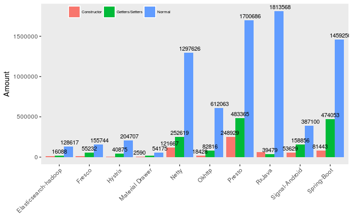

```r
#@TODO  Ver um Gráfico que Demonstre esses valores com a media/mediana dos commits
typeMethodsData <- summarise(group_by(methods, Project, typeMethod), Amount= sum(Count), MedianK = median(NtimeofCommits), MeanK = mean(NtimeofCommits))
#Amount
ggplot(typeMethodsData) +
  geom_bar(aes(x = Project, y = Amount, fill = typeMethod, group = typeMethod), position = "dodge", stat = "identity") +
  geom_text( aes(x = Project, y = Amount, label = round(Amount), group = typeMethod),
             check_overlap = TRUE, position = position_dodge(width = 1), vjust = -0.5, size = 3) +
  theme(axis.text.x = element_text(angle = 45, hjust = 1)) +
  theme(legend.position= c(0.25, 0.95), legend.direction="horizontal", legend.title = element_blank(),
        axis.title.x=element_blank(), legend.text=element_text(size=6), legend.background = element_rect(fill = "transparent", colour = NA)) +
  theme(panel.grid.minor = element_blank(),
        panel.grid.major = element_blank(),
        plot.background = element_rect(fill = "transparent", colour = NA))
```

- Gráfico dos projetos Contendo a Mediana dos Commits x Tipos de Metodos

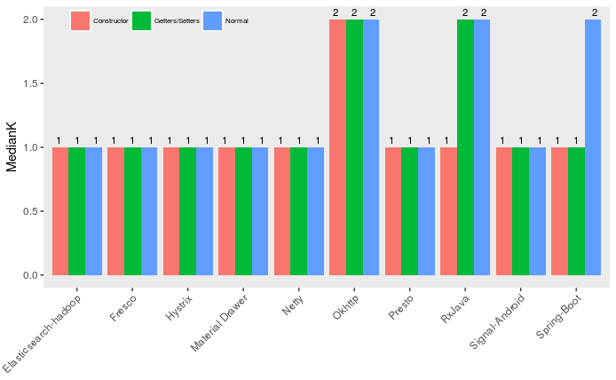

```r
#MedianK
ggplot(typeMethodsData) +
  geom_bar(aes(x = Project, y = MedianK, fill = typeMethod, group = typeMethod), position = "dodge", stat = "identity") +
  geom_text( aes(x = Project, y = MedianK, label = round(MedianK), group = typeMethod),
             check_overlap = TRUE, position = position_dodge(width = 1), vjust = -0.5, size = 3) +
  theme(axis.text.x = element_text(angle = 45, hjust = 1)) +
  theme(legend.position= c(0.20, 0.95), legend.direction="horizontal", legend.title = element_blank(),
        axis.title.x=element_blank(), legend.text=element_text(size=6), legend.background = element_rect(fill = "transparent", colour = NA)) +
  theme(panel.grid.minor = element_blank(),
        panel.grid.major = element_blank(),
        plot.background = element_rect(fill = "transparent", colour = NA))
```

- Gráfico dos projetos Contendo a media commits x Tipos de Metodos

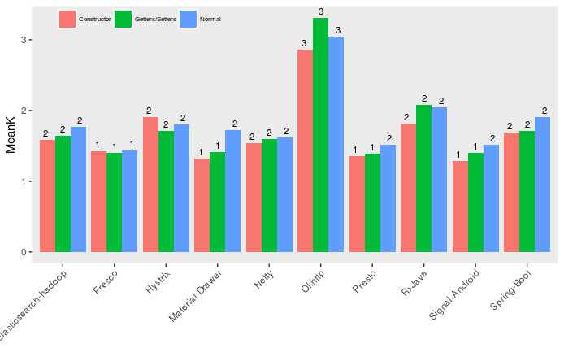

```r
#Mean
ggplot(typeMethodsData) +
  geom_bar(aes(x = Project, y = MeanK, fill = typeMethod, group = typeMethod), position = "dodge", stat = "identity") +
  geom_text( aes(x = Project, y = MeanK, label = round(MeanK), group = typeMethod),
             check_overlap = TRUE, position = position_dodge(width = 1), vjust = -0.5, size = 3) +
  theme(axis.text.x = element_text(angle = 45, hjust = 1)) +
  theme(legend.position= c(0.20, 0.95), legend.direction="horizontal", legend.title = element_blank(),
        axis.title.x=element_blank(), legend.text=element_text(size=6), legend.background = element_rect(fill = "transparent", colour = NA)) +
  theme(panel.grid.minor = element_blank(),
        panel.grid.major = element_blank(),
        plot.background = element_rect(fill = "transparent", colour = NA))
```

- Boxplot dos Projetos

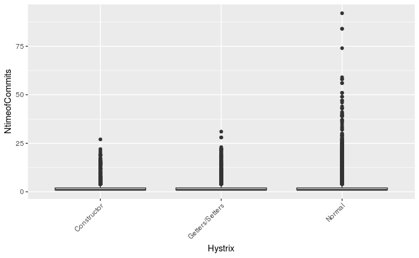

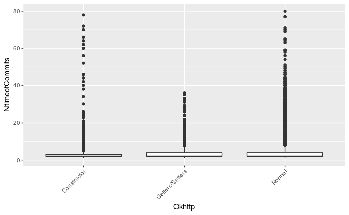

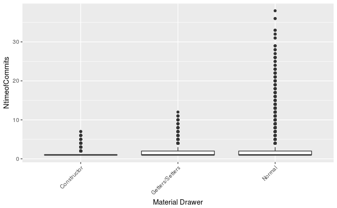

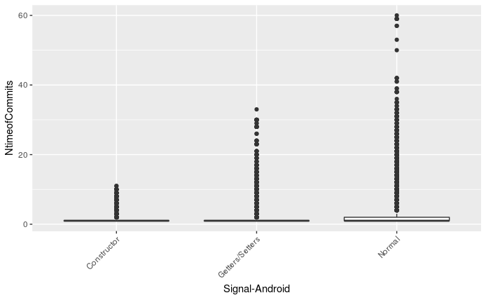

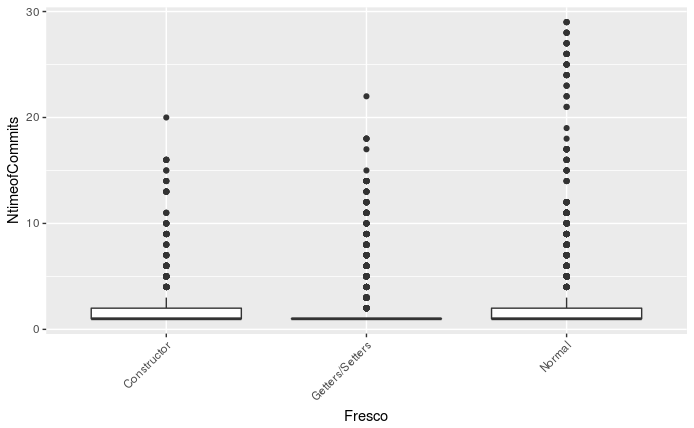

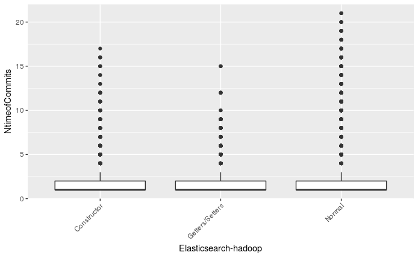

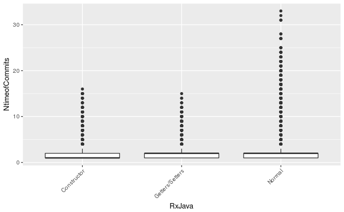

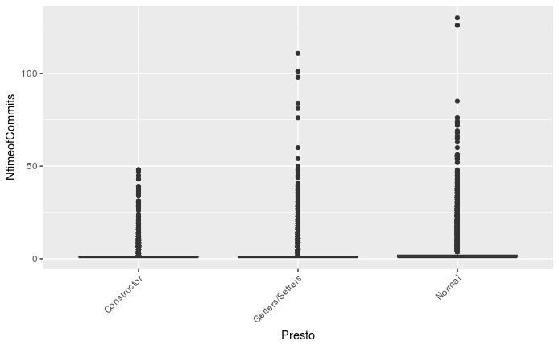

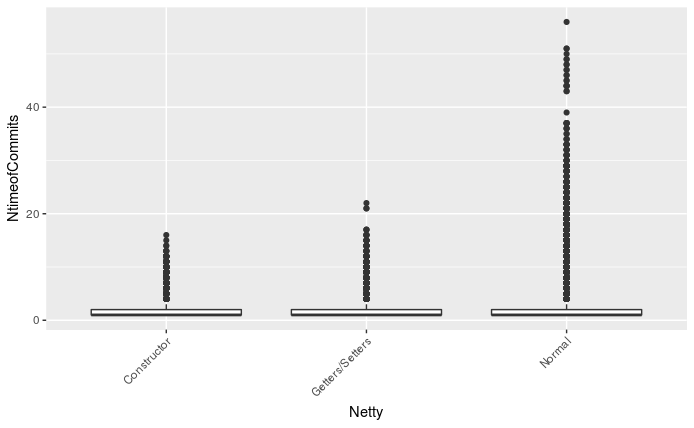

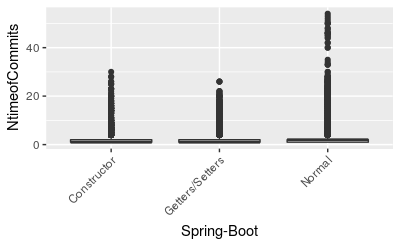

```r
#Boxplots por Projetos:
projects <- unique(methods$Project)
for (project in projects) {
  print(ggplot(filter(methods, Project == project), aes(x=typeMethod, y=NtimeofCommits)) +
    geom_boxplot() +
    theme(axis.text.x = element_text(angle = 45, hjust = 1)) +
    scale_x_discrete(name = project))
}
```

#### Boxplots Gerais:

- Boxplot dos metodos Normais:

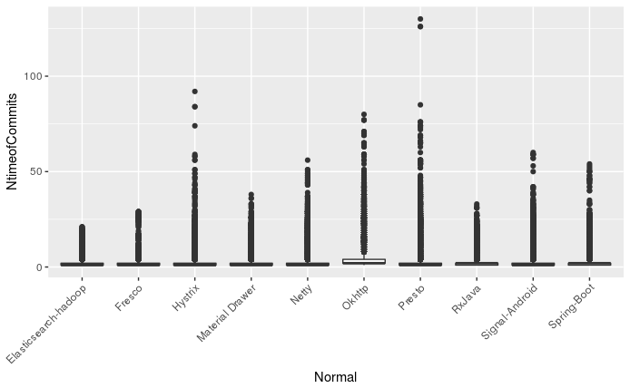

[figure not shown]

```r
ggplot(filter(methods, typeMethod == "Normal"), aes(x=Project, y=NtimeofCommits)) + geom_boxplot() +
  theme(axis.text.x = element_text(angle = 45, hjust = 1)) +
  scale_x_discrete(name ="Normal")
```

- Boxplot dos metodos Construtores:

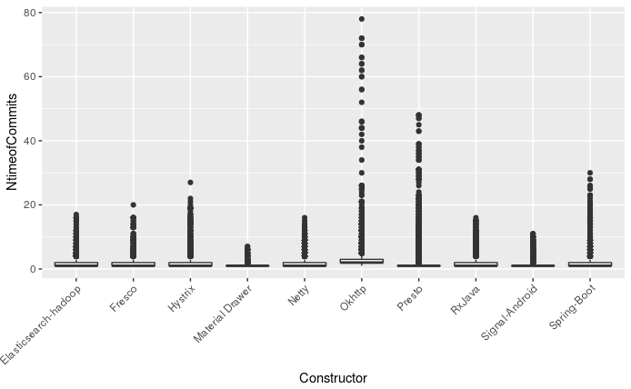

```r
ggplot(filter(methods, typeMethod == "Constructor"), aes(x=Project, y=NtimeofCommits)) + geom_boxplot() +
  theme(axis.text.x = element_text(angle = 45, hjust = 1)) +
  scale_x_discrete(name ="Constructor")
```

- Boxplot dos metodos de Getters and Setters:

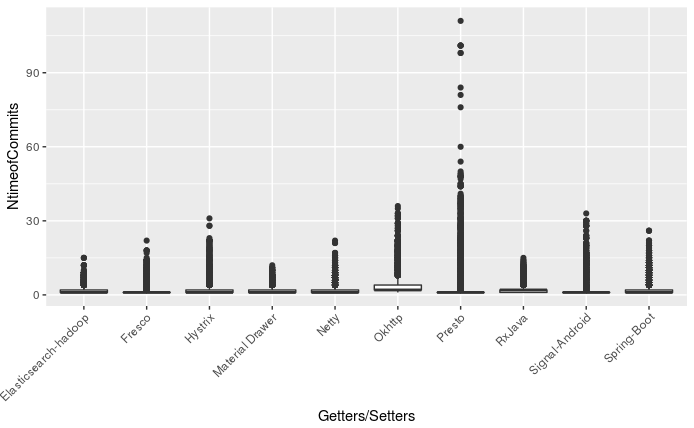

```r
ggplot(filter(methods, typeMethod == "Getters/Setters"), aes(x=Project, y=NtimeofCommits)) + geom_boxplot() +
  theme(axis.text.x = element_text(angle = 45, hjust = 1)) +
  scale_x_discrete(name ="Getters/Setters")
```

- Violin Plot de todos os Projetos

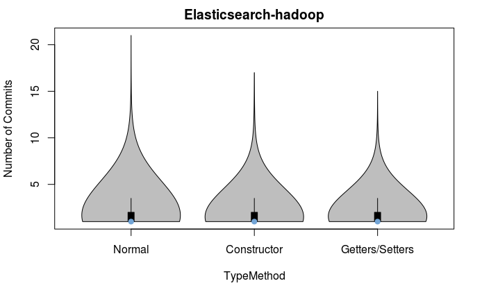

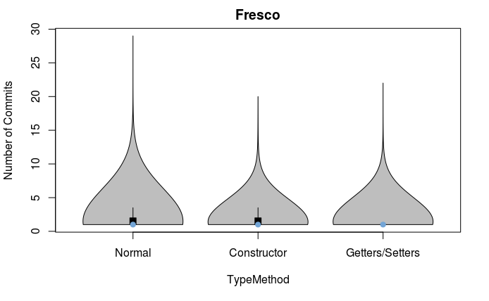

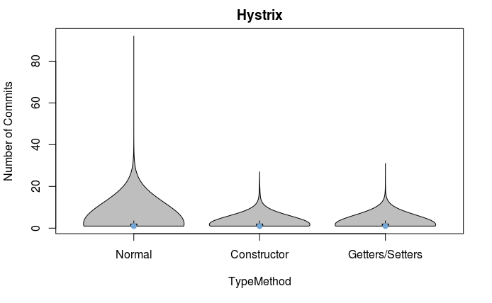

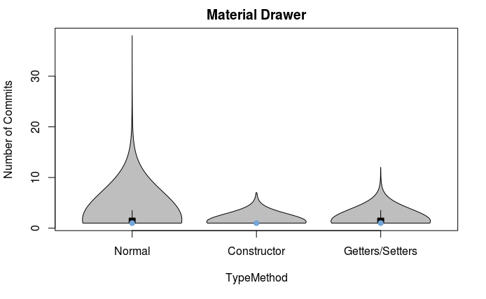

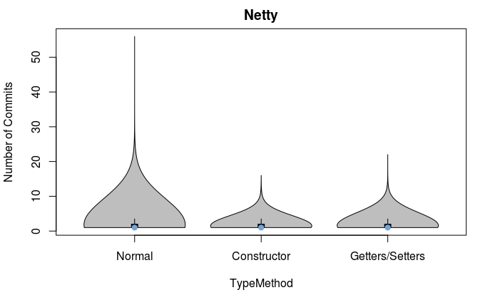

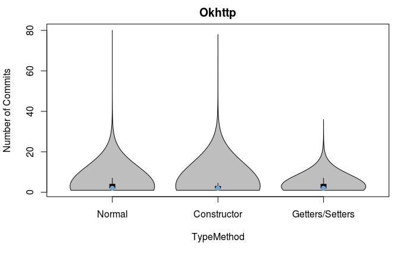

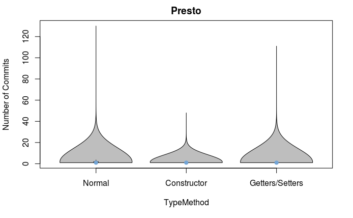

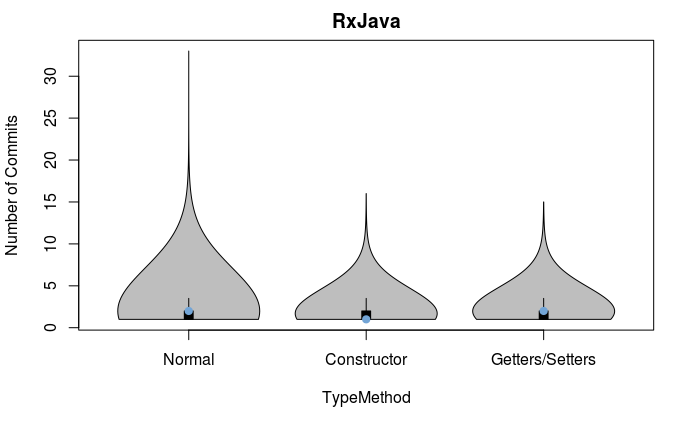

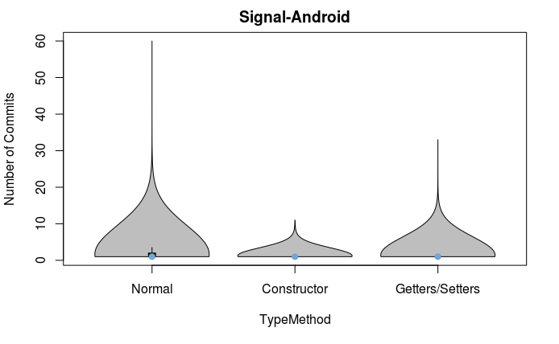

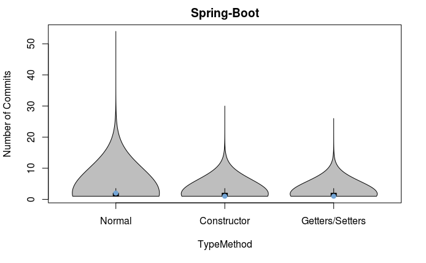

- Boxplot da Media do numero de commits por projeto:

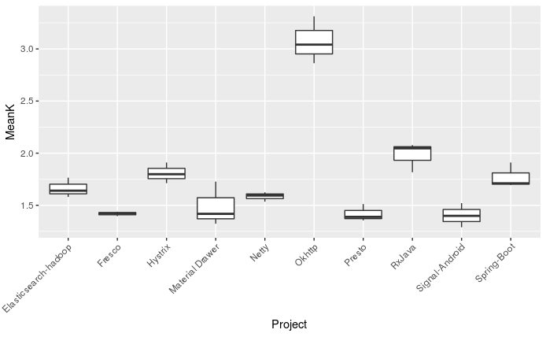

```r
ggplot(typeMethodsData, aes(x=Project, y=MeanK)) + geom_boxplot() +
  theme(axis.text.x = element_text(angle = 45, hjust = 1))
```

Explicar as constraints como esse comportamento ocorre ao longo das constraints de maneira profunda, ou seja, explicar porque algumas constraints diminui pouco a % e algumas muito.

```r
resultsC1C4<-
  sqldf(
    "SELECT Project, SUM(Count) as TotalTimeSeries,
     SUM(CASE WHEN (P2 = 1) AND (P1 = 1) THEN 1 ELSE 0 end) as 'C1',
     SUM(CASE WHEN (P2 = 1) AND (P1 = 1) AND (P4 = 1) THEN 1 ELSE 0 end) as 'C1-C2',
     SUM(CASE WHEN (P2 = 1) AND (P1 = 1) AND (P4 = 1) AND (P5 = 1) THEN 1 ELSE 0 end) as 'C1-C2-C3',
     SUM(CASE WHEN (P2 = 1) AND (P1 = 1) AND (P4 = 1) AND (P3 = 1) THEN 1 ELSE 0 end) as 'C1-C2-C4',
     SUM(CASE WHEN (P2 = 1) AND (P1 = 1) AND (P3 = 1) AND (P4 = 1) AND (P5 = 1) THEN 1 ELSE 0 end) as 'C1-C2-C3-C4'
     FROM methods
     GROUP BY Project"
  )

#resultsC1C4
```

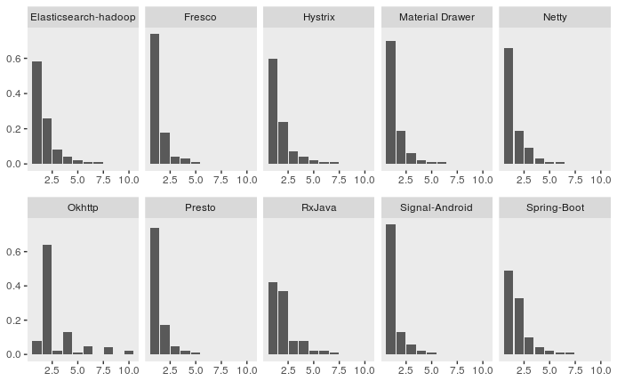

**TODO:** As mudanças ocorrem mais no inicio do ciclo de vida do metodo ou no final? #Já em relação aos bugs, as mudanças ocorrem em antes ou depois dos pontos de inserção dos bugs? Fazer um calculo que para cada commit, trazer a quantidade de dias entre os mesmos, calcular o range total, #e contar quais commits estao no 1st~4st quartil.

```r
summary(methods$NtimeofCommits)
```

```
   Min. 1st Qu.  Median    Mean 3rd Qu.    Max.
  1.000   1.000   1.000   1.805   2.000 130.000
```

**TODO:** Outro ponto é Mostrar se as series são estacionárias ou não? Quais são as vantagens de achar uma grande quantidade de #series estacionarias? Qual a diferença? existe alguma diferença em relação a variabilidade? tendência? etc. Como o foco não é mais com forecasting/predição. Tentar achar um motivo/vantagem na utilização de series estacionarias.

#### RQ2: How close is the relationship betweenthe history of bugs and changes?

Explicar de formar mais intuitiva como seria satisfizar o método de Granger, ou seja, ter um numero menor de casos positivos de granger é bom ou ruim? Quais suas vantagens? Menor Overhead? **TODO:** Um ponto interessante seria trazer a cobertura de bugs do modelo. Nesse caso seria interessante trazer para cada método o ID dos bugs.

Fazer um comparativo entre os resultados de granger e regressão? Explicar o motivo de Granger ter resultados menos positivos? Será que os metodos tem mais commits que RL? Nesse caso seria Fazer um boxplot/beanplot da diferença entre a tabela 3. analisando o histórico (anatomia dos metodos) entre as diferentes técnicas.

- Comparativo entre as tecnicas:

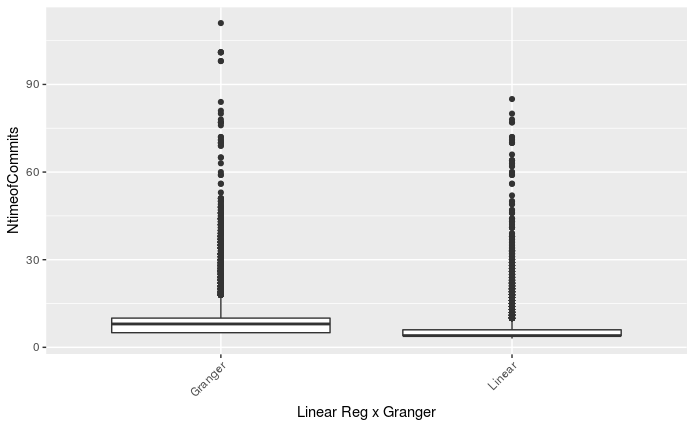

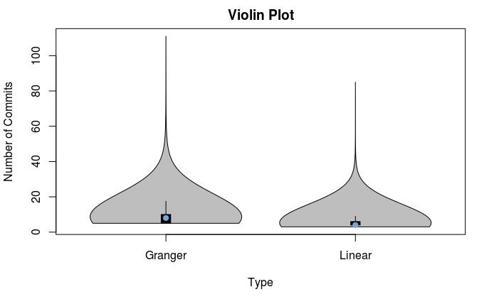